# Simulation of Exponential Distribution

Sam Hewamanage

August 4, 2014

The exponential distribution can be simulated in R with rexp(nosim, lambda) where lambda is the rate parameter. The mean of exponential distribution is 1/lambda and the standard deviation is also also 1/lambda. Set lambda = 0.2 for all of the simulations. In this simulation, you will investigate the distribution of averages of 40 exponential(0.2)s.

Illustrate via simulation and associated explanatory text the properties of the distribution of the mean of 40 exponential(0.2)s. You should

1. **Show where the distribution is centered at and compare it to the theoretical center of the distribution.**

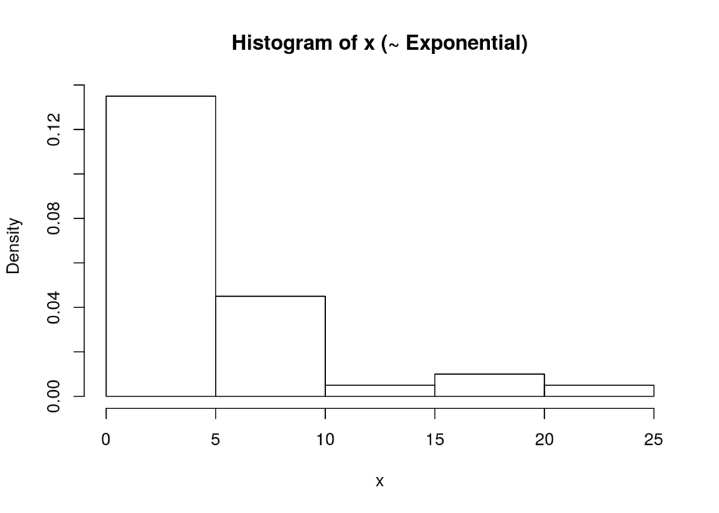

```r
set.seed(1234)
lambda <- 0.2
x <- rexp(40, lambda)
hist(x, probability=T, main="Histogram of x (~ Exponential)")
```

```r
theory.mean <- 1.0/lambda
exp.mean <- mean(x)
print ( cat('Experimental Mean =', exp.mean, ' compared to the theoretical mean, 1/lambda= ', theory.mean, '\n'))
```

```
## Experimental Mean = 4.969  compared to the theoretical mean, 1/lambda=  5
## NULL
```

Experimental values is quite close to the theoretical values. A very good approximation.

2. **Show how variable it is and compare it to the theoretical variance of the distribution.**

```r
theory.var <- 1.0/lambda^2
exp.var <- var(x)
print ( cat('Experimental Variance =', exp.var, ' compared to the theoretical Variance, 1/lambda = ', theory.var, "\n"))
```

```
## Experimental Variance = 25.99  compared to the theoretical Variance, 1/lambda =  25
## NULL
```

Experimental values is quite close to the theoretical values. A very good approximation.

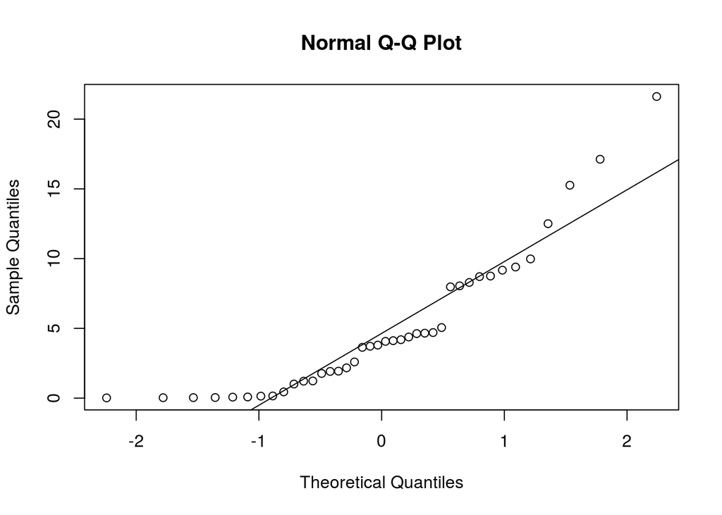

```r
qqnorm(x)
qqline(x)
```